# Practical Machine Learning Course Project

Cai Jiashen

8/1/2020

# Practical Machine Learning Course Project

## Background

Using devices such as Jawbone Up, Nike FuelBand, and Fitbit it is now possible to collect a large amount of data about personal activity relatively inexpensively. These type of devices are part of the quantified self movement – a group of enthusiasts who take measurements about themselves regularly to improve their health, to find patterns in their behavior, or because they are tech geeks. One thing that people regularly do is quantify how much of a particular activity they do, but they rarely quantify how well they do it. In this project, your goal will be to use data from accelerometers on the belt, forearm, arm, and dumbbell of 6 participants. They were asked to perform barbell lifts correctly and incorrectly in 5 different ways. More information is available from the website here: http://web.archive.org/web/20161224072740/http:/groupware.les.inf.puc-rio.br/har (see the section on the Weight Lifting Exercise Dataset).

Six young health participants were asked to perform one set of 10 repetitions of the Unilateral Dumbbell Biceps Curl in five different fashions: exactly according to the specification (Class A), throwing the elbows to the front (Class B), lifting the dumbbell only halfway (Class C), lowering the dumbbell only halfway (Class D) and throwing the hips to the front (Class E).

## Task

Create prediction models incorporating various measurements/data from personal activity devices to predict performance in doing Unilateral Dumbbell Biceps Curls.

## Loading Library

Loading required libraries.

```r
library(caret)
library(dplyr)
library(parallel)
library(doParallel)
library(rattle)
library(ggplot2)
```

## Loading Data Sets

Loading datasets and setting up factors.

```r
pml_train <- read.csv("pml-training.csv", na.strings=c("","NA"))
pml_test <- read.csv("pml-testing.csv", na.strings=c("","NA"))

pml_train$user_name <- factor(pml_train$user_name)
pml_test$user_name <- factor(pml_test$user_name)
pml_train$classe <- factor(pml_train$classe)

str(pml_train)
```

```
## 'data.frame':    19622 obs. of  160 variables:
##  $ X                       : int  1 2 3 4 5 6 7 8 9 10 ...
##  $ user_name               : Factor w/ 6 levels "adelmo","carlitos",..: 2 2 2 2 2 2 2 2 2 2 ...
##  $ raw_timestamp_part_1    : int  1323084231 1323084231 1323084231 1323084232 1323084232 1323084232 1323084232 1323084232 1323084232 1323084232 ...
##  $ raw_timestamp_part_2    : int  788290 808298 820366 120339 196328 304277 368296 440390 484323 484434 ...
##  $ cvtd_timestamp          : chr  "05/12/2011 11:23" "05/12/2011 11:23" "05/12/2011 11:23" "05/12/2011 11:23" ...
##  $ new_window              : chr  "no" "no" "no" "no" ...
##  $ num_window              : int  11 11 11 12 12 12 12 12 12 12 ...
##  $ roll_belt               : num  1.41 1.41 1.42 1.48 1.48 1.45 1.42 1.42 1.43 1.45 ...
##  $ pitch_belt              : num  8.07 8.07 8.07 8.05 8.07 8.06 8.09 8.13 8.16 8.17 ...
##  $ yaw_belt                : num  -94.4 -94.4 -94.4 -94.4 -94.4 -94.4 -94.4 -94.4 -94.4 -94.4 ...
##  $ total_accel_belt        : int  3 3 3 3 3 3 3 3 3 3 ...
##  $ kurtosis_roll_belt      : chr  NA NA NA NA ...
##  $ kurtosis_picth_belt     : chr  NA NA NA NA ...
##  $ kurtosis_yaw_belt       : chr  NA NA NA NA ...
```

[output cut: 86 more lines]

## Data Cleaning and Slicing

Cleaning up data - Removing empty variables ("" or "NA), variables with near zero variance.

```r
pml_train_clean <- select(pml_train, -c(X, raw_timestamp_part_1, raw_timestamp_part_2, cvtd_timestamp))
NZV <- nearZeroVar(pml_train_clean)
pml_train_clean <- pml_train_clean[,-NZV]
pml_train_clean <- pml_train_clean[,colSums(is.na(pml_train_clean)) == 0]

str(pml_train_clean)
```

```
## 'data.frame':    19622 obs. of  55 variables:
##  $ user_name           : Factor w/ 6 levels "adelmo","carlitos",..: 2 2 2 2 2 2 2 2 2 2 ...
##  $ num_window          : int  11 11 11 12 12 12 12 12 12 12 ...
##  $ roll_belt           : num  1.41 1.41 1.42 1.48 1.48 1.45 1.42 1.42 1.43 1.45 ...
##  $ pitch_belt          : num  8.07 8.07 8.07 8.05 8.07 8.06 8.09 8.13 8.16 8.17 ...
##  $ yaw_belt            : num  -94.4 -94.4 -94.4 -94.4 -94.4 -94.4 -94.4 -94.4 -94.4 -94.4 ...
##  $ total_accel_belt    : int  3 3 3 3 3 3 3 3 3 3 ...
##  $ gyros_belt_x        : num  0 0.02 0 0.02 0.02 0.02 0.02 0.02 0.02 0.03 ...
##  $ gyros_belt_y        : num  0 0 0 0 0.02 0 0 0 0 0 ...
##  $ gyros_belt_z        : num  -0.02 -0.02 -0.02 -0.03 -0.02 -0.02 -0.02 -0.02 -0.02 0 ...
##  $ accel_belt_x        : int  -21 -22 -20 -22 -21 -21 -22 -22 -20 -21 ...
##  $ accel_belt_y        : int  4 4 5 3 2 4 3 4 2 4 ...
##  $ accel_belt_z        : int  22 22 23 21 24 21 21 21 24 22 ...
##  $ magnet_belt_x       : int  -3 -7 -2 -6 -6 0 -4 -2 1 -3 ...
##  $ magnet_belt_y       : int  599 608 600 604 600 603 599 603 602 609 ...
```

[output cut: 41 more lines]

```r
inTrain <- createDataPartition(pml_train_clean$classe, p = 0.7, list = FALSE)
trainSet <- pml_train_clean[inTrain,]
testSet <- pml_train_clean[-inTrain,]
```

## Prediction Model

### Setup Parallel Computing

```r
cluster <- makeCluster(detectCores() - 1, setup_timeout = 0.5) # convention to leave 1 core for OS
registerDoParallel(cluster)
fitControl <- trainControl(method = "cv", number = 3, allowParallel = TRUE, verboseIter = TRUE)
```

### Decision Tree Model

```r
set.seed(2020)
modFitDT <- train(classe ~ ., data=trainSet, method="rpart", trControl=fitControl)
modFitDT
```

```
## CART
##
## 13737 samples
##    54 predictor
##     5 classes: 'A', 'B', 'C', 'D', 'E'
##
## No pre-processing
## Resampling: Cross-Validated (3 fold)
## Summary of sample sizes: 9158, 9159, 9157
## Resampling results across tuning parameters:
##
##   cp          Accuracy   Kappa
##   0.03870410  0.5656962  0.44276702
##   0.05449598  0.4697642  0.29265631
##   0.11585800  0.3388657  0.08326878
##
## Accuracy was used to select the optimal model using the largest value.
## The final value used for the model was cp = 0.0387041.
```

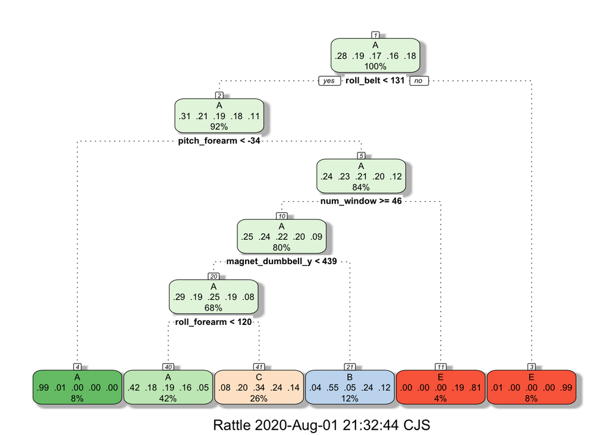

```r
fancyRpartPlot(modFitDT$finalModel)
```

```r
predictDT <- predict(modFitDT, newdata = testSet)
confMatrixDT <- confusionMatrix(predictDT, testSet$classe)
```

### Random Forest Model

```r
set.seed(2020)
modFitRF <- train(classe ~ ., data=trainSet, method="rf", trControl=fitControl)
modFitRF
```

```
## Random Forest
##
## 13737 samples
##    54 predictor
##     5 classes: 'A', 'B', 'C', 'D', 'E'
##
## No pre-processing
## Resampling: Cross-Validated (3 fold)
## Summary of sample sizes: 9158, 9159, 9157
## Resampling results across tuning parameters:
##
##   mtry  Accuracy   Kappa
##    2    0.9919196  0.9897778
##   30    0.9967968  0.9959483
##   58    0.9928656  0.9909752
##
## Accuracy was used to select the optimal model using the largest value.
## The final value used for the model was mtry = 30.
```

```r
predictRF <- predict(modFitRF, newdata = testSet)
confMatrixRF <- confusionMatrix(predictRF, testSet$classe)
```

### Gradient Boosted Model

```r
set.seed(2020)
modFitGBM <- train(classe ~ ., data=trainSet, method="gbm", trControl=fitControl, verbose = FALSE)
modFitGBM
```

```
## Stochastic Gradient Boosting
##
## 13737 samples
##    54 predictor
##     5 classes: 'A', 'B', 'C', 'D', 'E'
##
## No pre-processing
## Resampling: Cross-Validated (3 fold)
## Summary of sample sizes: 9158, 9159, 9157
## Resampling results across tuning parameters:
##
##   interaction.depth  n.trees  Accuracy   Kappa
##   1                   50      0.7574417  0.6922370
##   1                  100      0.8307479  0.7856443
##   1                  150      0.8700579  0.8355593
##   2                   50      0.8822151  0.8509215
##   2                  100      0.9395793  0.9235580
##   2                  150      0.9630923  0.9533012
##   3                   50      0.9308430  0.9124634
##   3                  100      0.9719008  0.9644546
##   3                  150      0.9858776  0.9821339
##
## Tuning parameter 'shrinkage' was held constant at a value of 0.1
##
## Tuning parameter 'n.minobsinnode' was held constant at a value of 10
## Accuracy was used to select the optimal model using the largest value.
## The final values used for the model were n.trees = 150, interaction.depth =
##  3, shrinkage = 0.1 and n.minobsinnode = 10.
```

```r
predictGBM <- predict(modFitGBM, newdata = testSet)
confMatrixGBM <- confusionMatrix(predictGBM, testSet$classe)
```

### Stop Parallel Computing

```r
stopCluster(cluster)
registerDoSEQ()
```

## Summarise Prediction Models

Summary of Prediction Models in terms of Accuracy and Kappa statistic.

```r
modelSummary <- data.frame(Model =c("Decision Tree", "Random Forest", "Gradient Boosting"), Accuracy = c(confMatrixDT$overall[1], confMatrixRF$overall[1], confMatrixGBM$overall[1]), Kappa = c(confMatrixDT$overall[2], confMatrixRF$overall[2], confMatrixGBM$overall[2]))
modelSummary
```

```
##               Model  Accuracy     Kappa
## 1     Decision Tree 0.5245540 0.3802158
## 2     Random Forest 0.9972812 0.9965611
## 3 Gradient Boosting 0.9898046 0.9871025
```

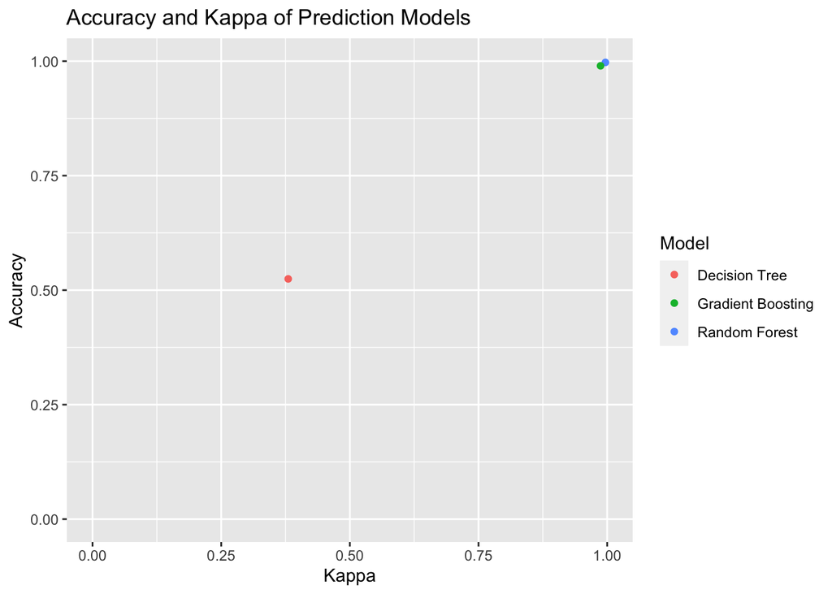

```r
ggplot(data = modelSummary, aes(x = Kappa, y = Accuracy, colour = Model)) +
  geom_point() +
  xlim(0, 1) + ylim (0, 1) +
  ggtitle("Accuracy and Kappa of Prediction Models")
```

## Apply Best Model to Test Data

Using the Random Forest model as it offers the best Accuracy and Kappa statistic.

```r
predictTest <- predict(modFitRF, newdata=pml_test)
predictTest
```

```
##  [1] B A B A A E D B A A B C B A E E A B B B
## Levels: A B C D E
```